# Analysis of Bike Sharing Data

Julia Olivieri

2023-02-28

## Data set

In this notebook we will be analyzing the bike sharing data set available [here](https://archive.ics.uci.edu/ml/machine-learning-databases/00275/). This data set includes observations from each day of 2011 and 2012 from Capital Bikeshare in Washington, D.C. The available variables are:

| Variable | Description |
| --- | --- |
| `season` | Either “winter”, “spring”, “summer”, or “fall” |
| `month` | Month of the year |
| `year` | Year (either 2011 or 2012) |
| `date` | Date |
| `date_noyear` | Date with the year set to 2000 for all entries (so dates can be compared across years) |
| `holiday` | TRUE if the day is a holiday, FALSE otherwise |
| `weekday` | Day of the week |
| `workingday` | TRUE if this is Monday - Friday, FALSE if it’s Saturday-Sunday |
| `weather` | Either “clear,” “cloudy,” or “rainy” |
| `temperature_F` | Temperature in degrees Fahrenheit |
| `casual` | Number of casual (non-registered) riders on the given day |
| `registered` | Number of registered riders on the given day |
| `count` | Number of total riders on the given day |
| `humidity` | Humidity (between 0 and 100) |
| `windspeed` | Wind speed in miles per hour |

## Exploratory data analysis

Let’s start by reading in the data.

```r
library(tidyverse)
bike_sharing <- read_csv("~/Desktop/COMP_162/datasets/bikesharing.csv")
head(bike_sharing)
```

```
## # A tibble: 6 × 15
##   season month    year date       date_noyear holiday weekday   workin…¹ weather
##   <chr>  <chr>   <dbl> <date>     <date>      <lgl>   <chr>     <lgl>    <chr>
## 1 winter January  2011 2011-01-01 2000-01-01  FALSE   Saturday  FALSE    cloudy
## 2 winter January  2011 2011-01-02 2000-01-02  FALSE   Sunday    FALSE    cloudy
## 3 winter January  2011 2011-01-03 2000-01-03  FALSE   Monday    TRUE     clear
## 4 winter January  2011 2011-01-04 2000-01-04  FALSE   Tuesday   TRUE     clear
## 5 winter January  2011 2011-01-05 2000-01-05  FALSE   Wednesday TRUE     clear
## 6 winter January  2011 2011-01-06 2000-01-06  FALSE   Thursday  TRUE     clear
## # … with 6 more variables: temperature_F <dbl>, casual <dbl>, registered <dbl>,
## #   count <dbl>, humidity <dbl>, windspeed <dbl>, and abbreviated variable name
## #   ¹workingday
```

### Descriptive statistics

Looking at the summary of the data set shows us more information about the data available to us. For example, the temperature ranges from 36 to 95 degrees Fahrenheit, and there’s a wide range in the number of bike riders per day (22 to 8714).

```r
summary(bike_sharing)
```

```
##     season             month                year           date
##  Length:731         Length:731         Min.   :2011   Min.   :2011-01-01
##  Class :character   Class :character   1st Qu.:2011   1st Qu.:2011-07-02
##  Mode  :character   Mode  :character   Median :2012   Median :2012-01-01
##                                        Mean   :2012   Mean   :2012-01-01
##                                        3rd Qu.:2012   3rd Qu.:2012-07-01
##                                        Max.   :2012   Max.   :2012-12-31
##   date_noyear          holiday          weekday          workingday
##  Min.   :2000-01-01   Mode :logical   Length:731         Mode :logical
##  1st Qu.:2000-04-01   FALSE:710       Class :character   FALSE:231
##  Median :2000-07-02   TRUE :21        Mode  :character   TRUE :500
##  Mean   :2000-07-01
##  3rd Qu.:2000-10-01
##  Max.   :2000-12-31
##    weather          temperature_F       casual         registered
##  Length:731         Min.   :36.40   Min.   :   2.0   Min.   :  20
##  Class :character   1st Qu.:56.85   1st Qu.: 315.5   1st Qu.:2497
##  Mode  :character   Median :68.80   Median : 713.0   Median :3662
##                     Mean   :68.56   Mean   : 848.2   Mean   :3656
##                     3rd Qu.:80.35   3rd Qu.:1096.0   3rd Qu.:4776
##                     Max.   :95.60   Max.   :3410.0   Max.   :6946
##      count         humidity       windspeed
##  Min.   :  22   Min.   : 0.00   Min.   : 1.50
##  1st Qu.:3152   1st Qu.:52.00   1st Qu.: 9.00
##  Median :4548   Median :62.70   Median :12.10
##  Mean   :4504   Mean   :62.79   Mean   :12.76
##  3rd Qu.:5956   3rd Qu.:73.00   3rd Qu.:15.60
##  Max.   :8714   Max.   :97.30   Max.   :34.00
```

We have access to a `weather` variable. Let’s check what values it takes on, and how many observations there are with each value:

```r
bike_sharing %>%
  group_by(weather) %>%
  summarize(count = n())
```

```
## # A tibble: 3 × 2
##   weather count
##   <chr>   <int>
## 1 clear     463
## 2 cloudy    247
## 3 rain       21
```

Looks like there are very few rainy days in our dataset.

Let’s check whether the weather seems to affect the number of riders:

```r
bike_sharing %>%
  group_by(weather) %>%
  summarize(avg_riders = mean(count))
```

```
## # A tibble: 3 × 2
##   weather avg_riders
##   <chr>        <dbl>
## 1 clear        4877.
## 2 cloudy       4036.
## 3 rain         1803.
```

It looks like when it rains there are fewer riders on average. Let’s see if the number of riders also changes with the season.

```r
bike_sharing %>%
  group_by(season) %>%
  summarize(avg_riders = mean(count))
```

```
## # A tibble: 4 × 2
##   season avg_riders
##   <chr>       <dbl>
## 1 fall        4728.
## 2 spring      4992.
## 3 summer      5644.
## 4 winter      2604.
```

We see that there are fewer riders in winter compared with the other months, which makes sense because of the relationship with the temperature.

### Data visualizations

Let’s visualize some of these relationships. We can start by creating pairwise scatterplots for a bunch of our quantitative variables:

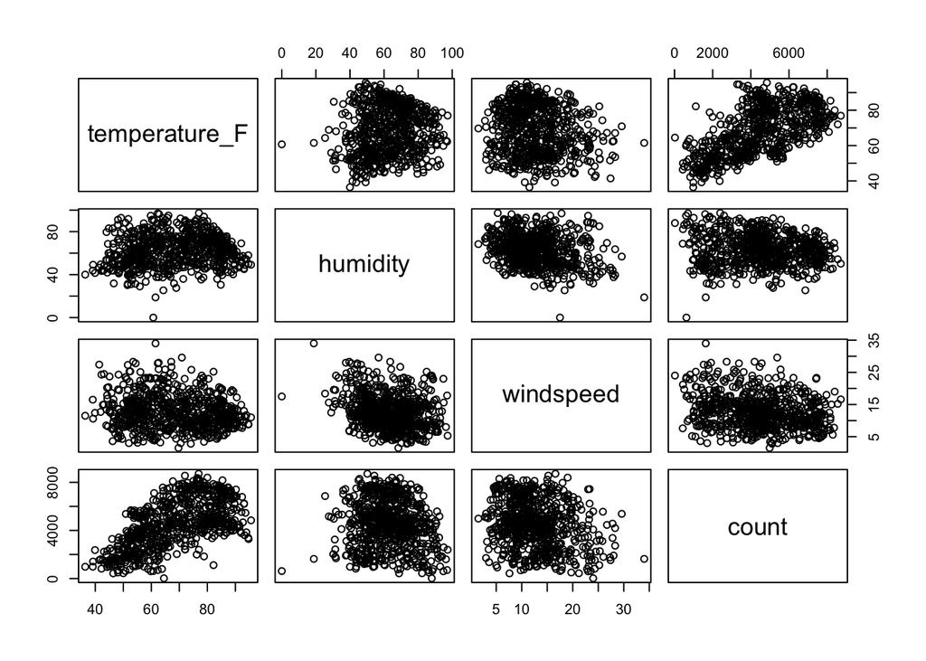

```r
bike_sharing %>%
  select(temperature_F, humidity, windspeed, count) %>%
  pairs()
```

Let’s look at the relationship between `temperature_F` and `count` more closely:

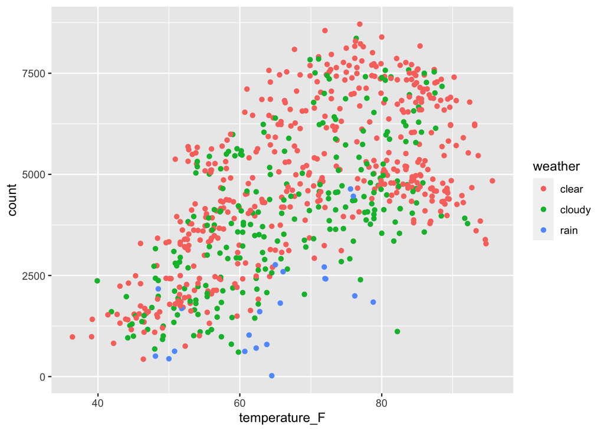

```r
ggplot(bike_sharing, aes(temperature_F, count,color=weather)) +
  geom_point()
```

This gives us a better sense of how `weather` and `temperature_F` influence `count`.

Finally, let’s check the number of riders by date:

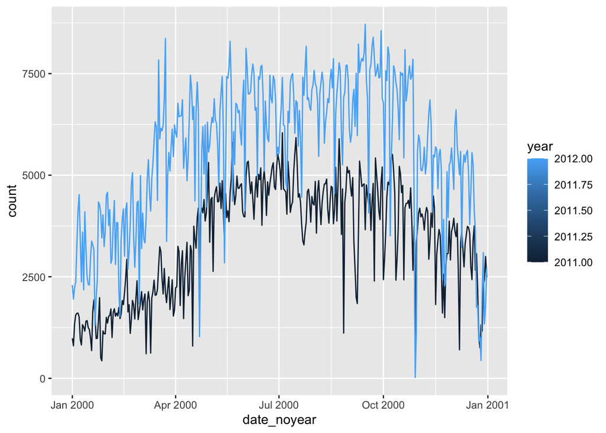

```r
ggplot(bike_sharing, aes(date_noyear, count,group=year,color=year)) +
  geom_line()
```

It looks like there were more riders in 2012 than in 2011. We might want to stick with an analysis of just one year because of this difference.

## Statistical analysis

### Correlations

Now we can formulate our hypotheses more clearly, and perform some statistical analyses. We’ll focus on only 2012. Let’s start by finding the correlations between the quantitative variables we’re interested in.

```r
bikeshare_2012 <- filter(bike_sharing, year == 2012)
bikeshare_2012 %>%
  select(temperature_F, humidity, windspeed, count) %>%
  cor()
```

```
##               temperature_F    humidity  windspeed       count
## temperature_F     1.0000000  0.11828645 -0.2034435  0.71374583
## humidity          0.1182865  1.00000000 -0.2909159 -0.08884533
## windspeed        -0.2034435 -0.29091588  1.0000000 -0.27923858
## count             0.7137458 -0.08884533 -0.2792386  1.00000000
```

Looking at our “pairs” plot above, there do seem to be some outliers. Let’s try a Spearman correlation as well:

```r
bikeshare_2012 %>%
  select(temperature_F, humidity, windspeed, count) %>%
  cor(method = "spearman")
```

```
##               temperature_F    humidity  windspeed       count
## temperature_F     1.0000000  0.13375046 -0.1789041  0.70012313
## humidity          0.1337505  1.00000000 -0.2935586 -0.05455316
## windspeed        -0.1789041 -0.29355861  1.0000000 -0.24685779
## count             0.7001231 -0.05455316 -0.2468578  1.00000000
```

### Developing hypotheses

Now that we’ve done a bunch of exploratory analysis, we have enough of a sense of our data to make some research hypotheses.

1. There is a relationship between the temperature and the number of riders.
2. There is a relationship between humidity and the number of riders.
3. There is a difference between the number of riders on a clear and cloudy day.
4. There is a difference between the number of riders on a Tuesday and a Thursday.

And here are the corresponding null hypotheses:

1. The slope of the regression line for `temperature_F` vs `count` is equal to zero.
2. The slope of the regression line for `humidity` vs `count` is equal to zero.
3. There is no difference between the population mean of `count` on a clear day vs `count` on a cloudy day.
4. There is no difference between the population mean of `count` on a Tuesday vs `count` on a Thursday.

### Testing hypotheses

Now that we’ve formulated these hypotheses, let’s test them. We can start with the linear models.

```r
print(summary(lm(count ~ temperature_F, data = bikeshare_2012)))
```

```
##
## Call:
## lm(formula = count ~ temperature_F, data = bikeshare_2012)
##
## Residuals:
##     Min      1Q  Median      3Q     Max
## -5116.2  -763.9   -35.0   958.7  2680.2
##
## Coefficients:
##                Estimate Std. Error t value Pr(>|t|)
## (Intercept)   -1197.201    355.704  -3.366 0.000845 ***
## temperature_F    98.223      5.052  19.442  < 2e-16 ***
## ---
## Signif. codes:  0 '***' 0.001 '**' 0.01 '*' 0.05 '.' 0.1 ' ' 1
##
## Residual standard error: 1255 on 364 degrees of freedom
## Multiple R-squared:  0.5094, Adjusted R-squared:  0.5081
## F-statistic:   378 on 1 and 364 DF,  p-value: < 2.2e-16
```

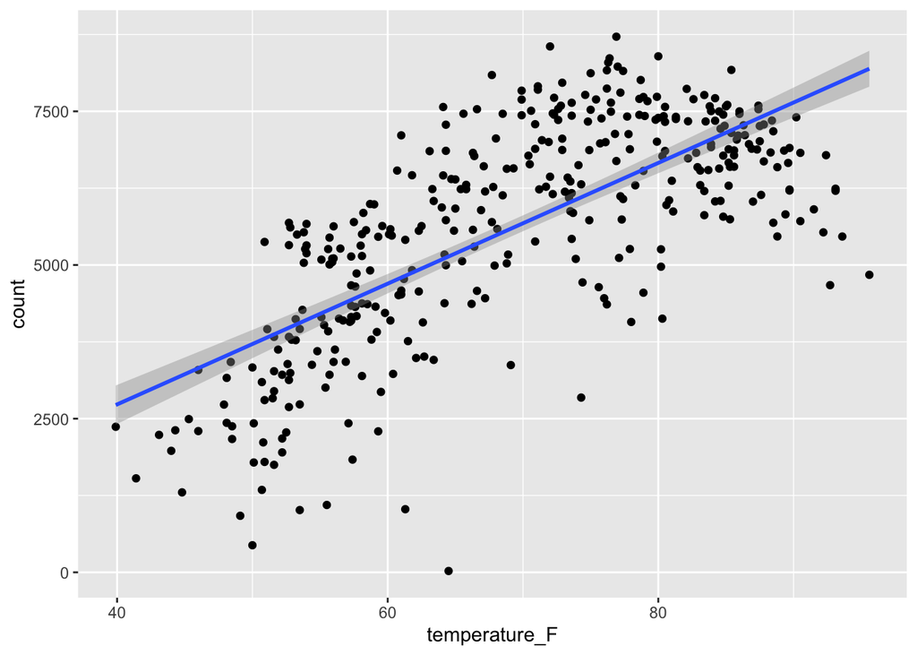

```r
ggplot(bikeshare_2012, aes(temperature_F, count)) +
  geom_point() +
  geom_smooth(method = lm)
```

We can reject the null hypothesis in this case. Now let’s test our second hypothesis:

```r
print(summary(lm(count ~ humidity, data = bikeshare_2012)))
```

```
##
## Call:
## lm(formula = count ~ humidity, data = bikeshare_2012)
##
## Residuals:
##     Min      1Q  Median      3Q     Max
## -5260.8 -1259.9   364.1  1446.1  2983.6
##
## Coefficients:
##             Estimate Std. Error t value Pr(>|t|)
## (Intercept) 6324.778    436.019  14.506   <2e-16 ***
## humidity     -11.840      6.957  -1.702   0.0896 .
## ---
## Signif. codes:  0 '***' 0.001 '**' 0.01 '*' 0.05 '.' 0.1 ' ' 1
##
## Residual standard error: 1784 on 364 degrees of freedom
## Multiple R-squared:  0.007893,   Adjusted R-squared:  0.005168
## F-statistic: 2.896 on 1 and 364 DF,  p-value: 0.08965
```

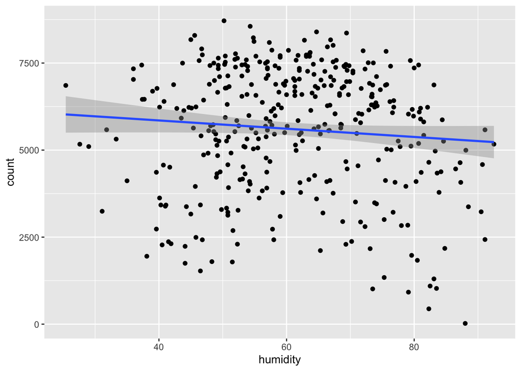

```r
ggplot(bikeshare_2012, aes(humidity, count)) +
  geom_point() +
  geom_smooth(method = lm)
```

Now, let’s perform our t-tests.

```r
norain_bikeshare_2012 <- filter(bikeshare_2012, weather != "rain")
t.test(count ~ weather, data = norain_bikeshare_2012)
```

```
##
##  Welch Two Sample t-test
##
## data:  count by weather
## t = 5.3257, df = 228.95, p-value = 2.399e-07
## alternative hypothesis: true difference in means between group clear and group cloudy is not equal to 0
## 95 percent confidence interval:
##   637.8395 1386.9621
## sample estimates:
##  mean in group clear mean in group cloudy
##             6003.734             4991.333
```

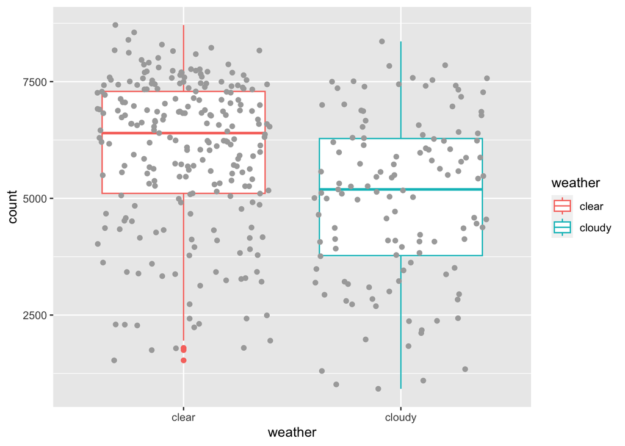

```r
ggplot(norain_bikeshare_2012, aes(weather,count)) +
  geom_boxplot(aes(color=weather)) +
  geom_jitter(color="darkgray")
```

We are able to reject the null hypothesis in this case.

Now let’s test our next hypothesis:

```r
tuethur_bikeshare_2012 <- filter(bikeshare_2012, weekday == "Tuesday" | weekday == "Thursday")
t.test(count ~ weekday, data = tuethur_bikeshare_2012)
```

```
##
##  Welch Two Sample t-test
##
## data:  count by weekday
## t = 1.3702, df = 101.69, p-value = 0.1737
## alternative hypothesis: true difference in means between group Thursday and group Tuesday is not equal to 0
## 95 percent confidence interval:
##  -190.0292 1038.9523
## sample estimates:
## mean in group Thursday  mean in group Tuesday
##               5977.750               5553.288
```

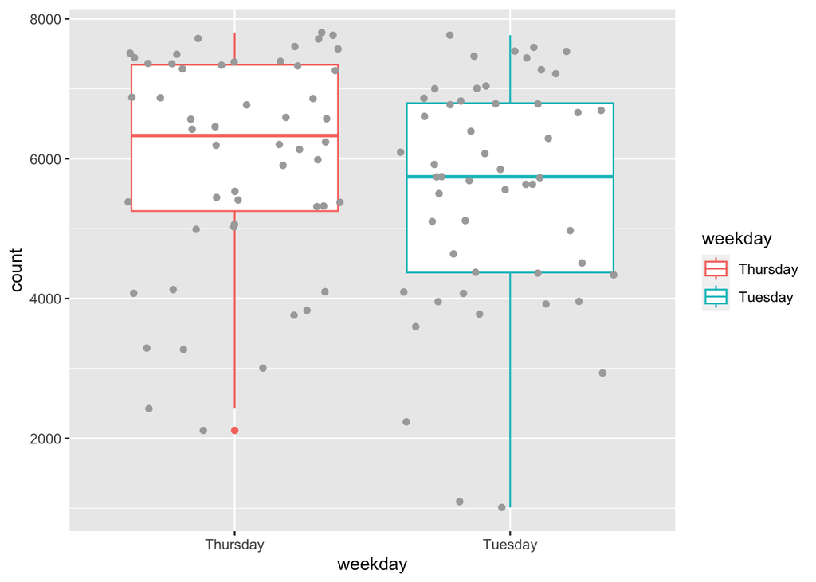

```r
ggplot(tuethur_bikeshare_2012, aes(weekday,count)) +
  geom_boxplot(aes(color=weekday)) +
  geom_jitter(color="darkgray")
```

In this case we fail to reject the null hypothesis.

## Conclusion

Based on our analysis of the bike sharing data from 2012, we found evidence of a positive relationship between `temperature_F` and `count`. Specifically, for every increase in degree, we see on average 98.223 more riders.

We also found evidence for a difference in the number of riders between clear and cloudy days. We are 95% confidence that the true difference is between 637 and 1386 riders more clear vs cloudy days.

We found no evidence that there is a relationship between humidity and number of riders, or a difference in number of riders on Tuesdays vs Thursdays.